# Demand 1

September 12, 2018

## Feedback

### Good:

- Videos were interesting and helpful
- Sapling exercises in class were very helpful!

### Needs improvement:

- Please explain Nash Equilibrium and Tit-for-Tat

## What is demand?

[interactive chart not shown]

[via GIPHY](https://giphy.com/gifs/candy-silly-demand-V9GZaqlnX3dsc)

## How do we estimate demand?

- Often estimated with surveys of **willingness to pay** (WTP), with which we can build up a **demand schedule**.
- **Demand Schedule** - *A table of quantity demanded at different price levels.*
- **Willingness to Pay** - *The maximum amount a person is willing to pay for a quantity of a good (e.g. eBay max).*

| Price | Quantity |
| --- | --- |
| 1 | 9500 |
| 10 | 8419 |
| 20 | 7764 |
| 30 | 7261 |
| 40 | 6838 |
| 50 | 6464 |

## A market model

A model of a market consists of:

- **Demand curve** - *A graphical representation of a demand schedule. A demand curve depicts how much quantity of a good would be demanded at different prices.*
- **Supply curve** - *A graphical representation of a supply curve, showing how much quantity of a good is supplied at different prices.*
- **Demand and supply curve shifts** - *A shift in demand or supply due to a change in income (for demand) or technology (for supply), or other factors.*
- **Market equilibrium** - *The point at which demand and supply is equal (i.e. the curves intersect).*
- **Changes in market equilibrium** - *How the market equilibrium changes in response to shifts in demand and supply.*

## Demand curves

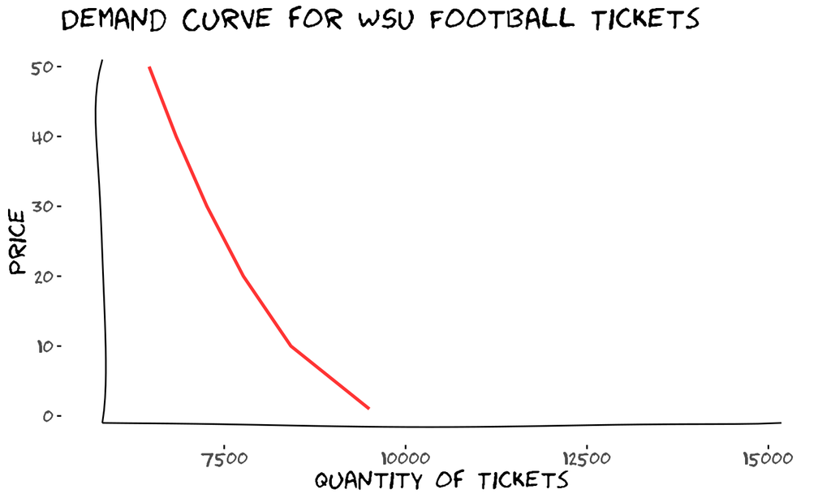

## Changes in demand

- **Movement along the demand curve** - *Due to a change in price, we move along the demand curve from the old price to the new price.*
- **Shift in the demand curve** - *If demand shifts, then the entire curve moves to the left or the right.*

*Review Practice Problem 1.*

## Shifts in Demand

Shifts in demand can occur because of changes in:

- **Population** - More people means more demand for goods, so the quantity demanded increases for any price point.
- **Income** - If a population becomes more wealthy overall, the demand curve can also shift (though also likely pivots).
- **Tastes** - Preferences can change in response to cultural shifts, major events, or fashion.
- **Expectations** - Expectations about the future can affect demand (e.g. an incoming hurricane increases bottled water purchases).
- **Number of consumers** - A change in the number of consumers, such as when the drinking age was raised to 21.

## Wrapping Up

- Complete the [knowledge check](https://goo.gl/forms/LQa51bqKHODk1Xlf2) for today’s participation point.
- Please provide [feedback](https://goo.gl/forms/8SiOwdi19kN8cINJ3) on today’s lecture.